# Statistik och dataanalys I

F5: Standardiserade variabler och normalfördelningen

Valentin Zulj

## Vad har vi gjort hittills

- Hittills har vi jämfört olika numeriska fördelningar
- Vi har ställt frågor i stil med
  - Hur kan vi visa skillnader mellan olika numeriska fördelningar med **låddiagram (boxplot)**?
  - Hur bedömer vi om en skillnad mellan grupper är **slumpmässig**?
  - Hur kan vi **transformera** värden så att skillader syns tydligare i ett diagram?

## Vad vi ska göra nu

- I dagens föreläsning ska vi fortsätta gräva i jämförelser
- Vi kommer fråga oss om det går att jämföra värden som är mätta på helt olika skalor/enheter
  - Går det t.ex. att göra en meningsfull jämförelse mellan **vikten** på en båt och **längden** på en lastbil?
  - *Ja, faktiskt!* Men för det behöver vi en ny typ av måttstock
- Den nya måttstocken kallas för **Z-värde**, och är ett resultat av standardisering
- Z-värden och standardisering kommer leda oss till **normalfördelningen**, som är central för statistiken

# Z-värden och standardisering

## z-värde - ett mått med standardavvikelser som enhet

- **Z-värdet (z-score)** mäter avvikelsen från genomsnittet för en variabel – mätt i antalet standardavvikelser
- **Exempel**
  - Kursboken (sid 152) jämför en länghoppare som hoppar 6.58 meter med en löpare som springer 200 meter på 23.26 sekunder i OS 2016
  - Vi kan inte jämföra en längd i meter med en tid i sekunder
  - Men: vi **kan** jämföra hur många **standardavvikelser** respektive prestation avviker från den **genomsnittliga deltagaren** i respektive tävling

## Z-värde

- **Exempel, fortsättning**
  - Vi kan räkna ut att vinnaren i längdhopp hoppade **1.66 standardavvikelser längre** än det genomsnittliga hoppet i tävlingen
  - Vi kan också räkna ut att vinnaren i 200 meter sprang på en tid som var **2.02 standardavvikelser mindre** än den genomsnittliga tiden i tävlingen
  - **Slutsats:** Vinnaren i 200 meter gjorde en mer imponerande insats, åtminstone i relation till övriga insatser som gjordes i de båda grenarna
- Vi jämför fortfarande varje insats med genomsnittet i sin gren, men eftersom vi byter skala kan vi jämföra **mellan** grenar också!

## Standardavvikelser

- Vi pratade om standardavvikelser på F2 – här kommer en kort repetition
- För en numerisk variabel $y$ är standardavvikelsen
  $$s_y = \sqrt{s_y^2}$$
- $s_y^2$ står för variansen, som vi räknar ut med
  $$s_y^2 = \cfrac{\sum_{i=1}^n(y_i - \bar{y})^2}{n-1}$$
- Om vi hellre vill räkna ut standardavvikelsen i ett enda steg blir formeln
  $$s_y = \sqrt{\cfrac{\sum_{i=1}^n(y_i - \bar{y})^2}{n-1}}$$

## Att räkna ut z-värdet

- Vi konstaterade att vinnaren i längdhopp hoppade 1.66 standardavvikelser längre än det genomsnittliga hoppet i tävlingen
- Med andra ord hade vinnarens bästa hopp ett z-värde på 1.66 – men *hur räknar vi ut det?*
- Om värdet på en observation betecknas $y$, och om $\bar y$ och $s$ betecknar genomsnittet och standardavvikelsen för variabeln $y$, så är z-värdet
  $$z = \cfrac{y - \bar{y}}{s}$$
- För att räkna på z-värden behöver vi en numerisk fördelning (hur skulle vi räkna ut t.ex. standardavvikelse för en kategorisk fördelning?)

## Att räkna ut z-värdet

- I vårt exempel var den genomsnittliga hopplängden i tävlingen $\bar{y} = 6.17$ meter, och standardavvikelsen var $s = 0.247$ meter
- Z-värdet för ett hopp på $y = 6.58$ meter blir så
  $$z = \cfrac{y - \bar{y}}{s} = \cfrac{6.58 - 6.17}{0.247} = 1.66$$
- Därför säger vi att vinnaren hoppade 1.66 standardavvikelser högre än genomsnittshoppet i tävlingen

## Att räkna ut z-värdet

- Vi gör samma beräkning för vinnaren i 200-meterslöpning för att bekräfta att z-värdet för den bästa löptiden är 2.02
- Den genomsnittliga tiden var $\bar{y} = 24.58$ sekunder och standardavvikelsen var $s=0.654$ sekunder
- Därför blir z-värdet för segertiden på 23.26 sekunder blir därför
  $$z = \cfrac{y - \bar{y}}{s} = \cfrac{23.26 - 24.58}{0.654} = -2.02$$
- Notera att z-värdet vi räknade ut är **negativt**, vilket betyder att observationen är **mindre** än genomsnittet
- När de handlar om tiden för ett lopp är 2.02 standardavvikelser mindre samma sak som 2.02 standardavvikelser bättre (då man vill springa snabbt)

## Att översätta mellan skalor

- Att översätta från en annan enhet (t.ex kg eller meter) till enheten standardavvikelser är som att översätta mellan vilka två enheter som helst
- En mile är t.ex. $\approx$ 1.6 kilometer – om avståndet mellan två punkter är 12 km, så är avståndet i miles $12/1.6 = 7.5$
- På samma sätt: om avståndet mellan $y$ och $\bar{y}$ är 5 km, och varje standardavvikelse är 2 km, så blir avståndet i standardavvikelser $5 / 2 = 2.5$
- En viktig skillnad är att en mile alltid är ungefär 1.6 km, men storleken på en standardavvikelse varierar från fall till fall

## Att räkna ut originalvärdet med hjälp av z-värdet

- Vi har sett hur vi kan räkna ut z-värdet för en observation, alltså det antalet standardavvikelser som observationen skiljer sig från genomsnittet
- Vi kan också vilja besvara frågor som: hur långt måste du hoppa i längd för att hoppa **två standardavvikelser över genomsnittet**?
- Det kan vi se genom att skriva om vår formel:
  $$z = \cfrac{y - \bar{y}}{s} \implies y = \bar{y} + zs$$
- Vi antar att $\bar{y} = 6.17$ meter, $s=0.247$ meter för längdhopp
- Du måste då hoppa $6.17 + 2 \cdot 0.247 = 6.664$ meter för att ditt hopp ska vara två standardavvikelser över genomsnittet
- **Fråga:** Hur långt måste du hoppa för att z-värdet ska vara större än 0?

## Standardiserade variabler

- Vi har sett att z-värdet räknas ut med formeln
  $$z = \cfrac{y - \bar{y}}{s}$$
- Om vi har en variabel $y$ med medelvärde $\bar{y}$ och standardavvikelse $s$, kan vi visa att
  - den nya variabeln $y - \bar{y}$ har då medelvärde $0$, och variabelns standardavvikelse är fortfarande $s$
  - Den nya ariabeln $z = (y - \bar{y})/s$ har medelvärde $0$ och standardavvikelse $1$
- Eftersom $z$ alltid har medelvärde $0$ och standardavvikelse $1$, oavsett vilka värden vi har på variabeln $y$, säger vi att $z$ är en **standardiserad variabel**

## z är en standardiserad variabel

- Med hjäp av `R` kan vi visa att föregående slide stämmer
- Vi läser in ett dataset som innehåller 32 bilmodeller, den första bilmodellen är exempelvis en Mazda RX4
- För varje modell skiver vi ut variabeln *mpg* (miles per gallon)

```r
suppressWarnings(library(mosaic)) # dödar onödig output
data(mtcars)
y <- mtcars$mpg
y
```

```
 [1] 21.0 21.0 22.8 21.4 18.7 18.1 14.3 24.4 22.8 19.2 17.8
[12] 16.4 17.3 15.2 10.4 10.4 14.7 32.4 30.4 33.9 21.5 15.5
[23] 15.2 13.3 19.2 27.3 26.0 30.4 15.8 19.7 15.0 21.4
```

## z är en standardiserad variabel

- Vi kan titta på några mått som sammanfattar vår variabel

```r
favstats(y) |> round(3) # avrundar till 3 decimaler
```

```
  min     Q1 median   Q3  max   mean    sd  n missing
 10.4 15.425   19.2 22.8 33.9 20.091 6.027 32       0
```

- Vi ser att medelvärdet är ca 20 mpg, och standardavvikelsen ungefär 6 mpg

## z är en standardiserad variabel

- För varje observation av $y$ subtraherar vi medelvärdet och delar med standardavvikelsen
- Vi skriver ut våra värden för den nya variabeln z
- **Tolka:** Vad säger dessa värden exempelvis om modellen Mazda RX4, som är den första bilen i vårt dataset?

```r
z <- (y - mean(y)) / sd(y)
z |> round(3)
```

```
 [1]  0.151  0.151  0.450  0.217 -0.231 -0.330 -0.961  0.715
 [9]  0.450 -0.148 -0.380 -0.612 -0.463 -0.811 -1.608 -1.608
[17] -0.894  2.042  1.711  2.291  0.234 -0.762 -0.811 -1.127
[25] -0.148  1.196  0.980  1.711 -0.712 -0.065 -0.845  0.217
```

## z är en standardiserad variabel

- Vi tittar på några mått som sammanfattar vår standardiserade variabel $z$.

```r
favstats(z) |> round(3) #Vi avrundar till 3 decimaler
```

```
    min     Q1 median   Q3   max mean sd  n missing
 -1.608 -0.774 -0.148 0.45 2.291    0  1 32       0
```

- Vi har nu medelvärdet 0 och standardavvikelsen 1
- Det överensstämmer med vad vi kunde förvänta oss utifrån teorin

## z är en standardiserad variabel

# Normalfördelningen

## Normalfördelningen

- Under F2 tittade vi på histogram, och sa att formen på ett histogram beskriver hur värden på en variabel **fördelar sig**
- Normalfördelningen beskriver en speciell typ av fördelning
- Figuren till vänster är en **normalfördelningskurva**, och figuren till höger är ett histogram som visar en normalfördelad variabel
- Histogrammet har ungefär samma form som normalfördelningskurvan

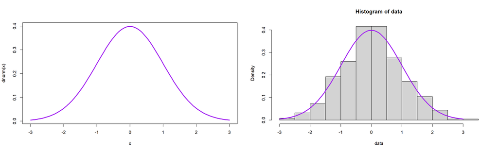

## Normalfördelningen

- Formen på en normalfördelningskurva påminner om en kyrkklocka, och denna typ av kurva kallas ibland också för just *bell curve*
- Fördelningen kan ibland kallas för en *Gaussisk fördelning*, men i den här kursen kommer vi konsekvent att använda termen normalfördelning

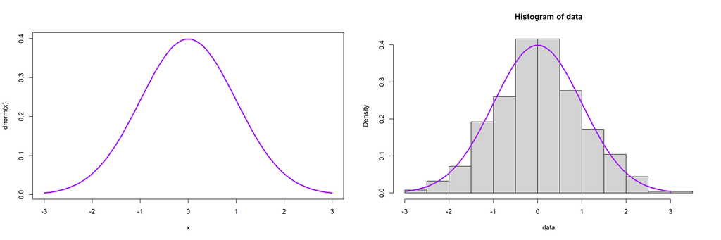

## Normalfördelningen

- Om en variabel är normalfördelad kan vi med hjälp av detta räkna ut hur stor andel av observationerna som ligger inom ett visst intervall
- Arean under normalfördelningskurvan representerar 100% av våra observationer
- Skalan på x-axeln i figuren visar antalet standardavvikelser från medelvärdet (z-värdet)

## Normalfördelningen

- I normalfördelningen ligger
  - 68% av alla observationer inom en standardavvikelse från medelvärdet
  - 95% av alla observationer inom 2 standardavvikelser från medelvärdet
  - 99.7% av alla observationer inom 3 standardavvikelser från medelvärdet

## Räkneexempel 1

- Låt oss använda det vi vet om normalfördelningen för att **göra beräkningar!**
- Anta att hopplängderna i en längshoppstävling är normalfördelade
  - Hur stor andel av hoppen är antingen minst två standardavvikelser större eller minst två standardavvikelser mindre än genomsnittet?

## Räkneexempel 2

- Hur stor andel av hoppen är minst en standardavvikelse längre än snittet?
- För att lösa denna uppgift behöver vi introducera en ny egenskap hos normalfördelningen, nämligen att den är **symmetrisk**
- Vi ser att normalfördelningskurvan speglar sig runt värdet 0 på x-axeln, det är alltså lika många observationer till vänster om 0 som till höger om 0
- Vi har så att 50% av observationerna är mindre än 0, och 50% är större än 0

## Räkneexempel 2

- Med hjälp av fördelningens symmetri kan vi komma fram till att
  - Av hoppen som ligger mellan -1 och 1, ligger hälften till höger om 0 (alltså $68\%/2=34\%$ av alla hopp)
  - $50\%$ av alla hopp ligger till höger om noll, och $34\%$ ligger mellan 0 och 1
  - Vi får därför att andelen hopp till höger om 1 är $50\% - 34\% = 16\%$
- Andelen hopp som är minst en standardavvikelse längre än snittet är så $16\%$

## Räkneexempel 3

- Vi antar att genomsnittshoppet är $\bar{y}=4.2$ meter, och att standardavvikelsen är $s=0.4$ meter
- Hur långt måste ett hopp minst vara **i meter** för att vara bland de $16 \%$ längsta hoppen?
- Det här är ett mer intressant exemepel än de tidigare: frågan är ställd i vanliga enheter (alltså meter) och inte standardavvikelser
- Detta är intressant då vi vanligtvis tänker i vanliga enheter, men vi har bara pratat om normalfördelningen i enheten standardavvikelser
- Vad kan vi göra för att lösa detta problem?
- Vi kan översätta mellan skalor!

## Räkneexempel 3

- Hur långt måste ett hopp minst vara **i meter** för att vara bland de $16 \%$ längsta hoppen, när $\bar{y}=4.2$ meter, och $s=0.4$ meter?
- För att vara bland de $16 \%$ längsta hoppen måste hoppet vara minst $1$ standardavvikelse längre än genomsnittet (från Räkneexempel 2)
- Vi vill översätta gränsen till meter, och använder formeln från innan
  $$z = \cfrac{y - \bar{y}}{s} \implies y = \bar{y} + zs$$
- Hoppet måste alltså vara $\bar{y} + 1 \cdot s$ meter för att vara en standardavvikelse från snittet
- Vi stoppar in våra siffror, och får gränsen $\bar{y} + 1 \cdot s = 4.2 + 1 \cdot 0.4 = 4.6$ meter

## Percentiler

- I F2 pratade vi lite kort om **percentiler**
- Om vi har en numerisk variabel så är en percentil ett värde som är större än en viss specificerad procentandel av observationerna
- **Exempel:**
  - Den 75:e percentilen är ett värde som är större än ungefär 75 procent av observationerna och mindre än ungefär 25 procent av observationerna
  - Den 75:e percentilen är alltså samma sak som den tredje kvartilen Q3

## Normalfördelningstabeller

- Normalfördelningstabellen, som vi här ser en liten del av, kan användas för att **översätta z-värden till proportioner, eller proportioner till z-värden**
- Ett z-värde får du genom att kombinera talen i den vänstra marginalen med talen i den övre marginalen
- För varje z-värde anger tabellen en proportion som ligger *till vänster* om detta z-värde

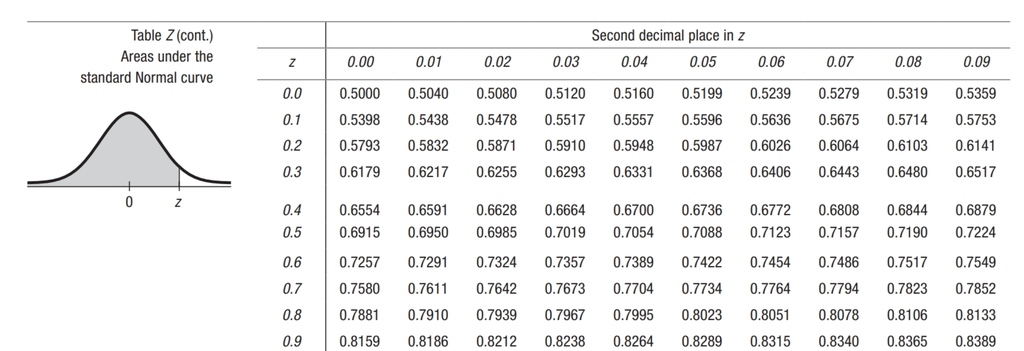

## Normalfördelningstabeller – koppling till exempel

- Vi behåller kopplingen till vår längdhoppstävling, och tolkar tabellvärdet i det sammanhanget
- Om någon gör ett hopp som är 0.32 standardavvikelser längre än snittet, så är det hoppet längre än 62.55% av alla hopp i tävlingen

## Normalfördelningstabeller

- Vi vill sällan åt z-värdet i sig, utan det är bara ett led i våra beräkningar
- Z-värdet låter oss översätta mellan originalenheten på vår variabel (meter, kg, kronor, etc) och en proportion i procent, vilket kan vara hjälpsamt
- Om vi har ett värde i originalskalan och vill veta andelen observationer som är mindre eller större än detta värde:
  $$\text{y-värde} \implies \text{z-värde} \implies \text{andel i procent}$$
- Om vi vill veta vad värdet i originalskalan behöver vara för att en bestämd andel av observationerna ska vara mindre/större:
  $$\text{andel i procent} \implies \text{z-värde} \implies \text{y-värde}$$
- Låt oss göra en uträkning av varje slag!

## Normalfördelningstabeller – räkneexempel 1

- Åter till vår längdhoppstävling, där genomsnittshoppet är $\bar{y}=4.2$ meter, och standardavvikelsen är $s=0.4$ meter
- Vi gör ett hopp om $y=4.5$ meter, och vill nu veta andelen hopp som är kortare respektive längre än vårat
- Vi har ett värde på originalskalan, och gör våra uträkningar enligt
  $$\text{y-värde} \implies \text{z-värde} \implies \text{andel i procent}$$
- Vi beräknar z-värdet med formeln
  $$z = \cfrac{y - \bar{y}}{s} = \cfrac{4.5 - 4.2}{0.4}=0.75$$
- Vårt hopp var alltså 0.75 standardavvikelser längre än genomsnittshoppet

## Normalfördelningstabeller – räkneexempel 1

- Vi har räknat ut att vårt hopp var 0.75 standardavvikelser längre än genomsnittshoppet, alltså att z-värdet är alltså 0.75
- För att se andelen hopp som har ett **lägre** z-värde än 0.75 använder vi normalfördelningstabellen
- På raden med $0.7$ i vänstermarginalen, och i kolumnen med $0.05$ i övre marginalen, hittar vi $0.7734$ (kontrollera gärna detta själv!)
- **Slutsats:** Ungefär 77.34 procent av alla hopp i tävlingen är kortare än vårt hopp, vilket betyder att 22.66 procent av hoppen är längre
- Vi kan, om vi vill, säga att ett hopp på 4.5 meter befinner sig ungefär vid den 77:e percentilen i förhållande till övriga hopp i tävlingen

## Normalfördelningstabeller – räkneexempel 2

- Vårt senaste hopp var inte bland de 10 procent längsta, men hur långt måste vi hoppa om vi har det målet? (fortfarande med $\bar{y}=4.2$ m och $s=0.4$ m)
- Den här gången har vi en andel, och vill tillbaka till originalskalan, så vi räknar enligt
  $$\text{andel i procent} \implies \text{z-värde} \implies \text{y-värde}$$
- Vi vill hoppa så långt att minst 90 procent av hoppen i tävlingen är kortare än vårt hopp
- Detta är samma sak som att vårt hopp måste ligga över den 90:e percentilen

## Normalfördelningstabeller – räkneexempel 2

- Nu letar vi efter andelen 0.9 i normalfördelningstabellen (exakt 0.9 finns inte i tabellen, men vi tar 0.8997 som är närmast)
- Andelen 0.8997 finns på en rad med 1.2 i sidomarginalen, och i en kolumn med 0.08 i övre marginalen
- Vi sätter ihop detta till ett z-värde om 1.28, och får att vårt hopp måste vara minst 1.28 standardavvikelser längre än genomsnittet för att vara topp 10%
- Nu återstår bara att omvandla z-värdet till meter, med formeln
  $$y = \bar{y} + zs = 4.2 + 1.28 \cdot 0.4 = 4.712$$
- **Slutsats:** Vi måste hoppa längre än 4.712 meter för att vårt hopp ska vara topp 10%

## Normalfördelningstabeller i R

- Funktionerna *qnorm* och *pnorm* är kopplade till normalfördelningstabeller
- Vi använder `pnorm()` när vi har ett z-värde, och vill veta hur stor andel av observationerna i en normalfördelning som har ett lägre z-värde
- I ett av våra exempel ville vi veta hur stor andel av längdhoppen som hade ett mindre z-värde än 0.75, och tabellen gav oss då 77.34 procent
- I R gör vi motsvarande beräkning på följande sätt

```r
pnorm(0.75)
```

```
[1] 0.7733726
```

## Normalfördelningstabeller i R

- Funktionerna *qnorm* och *pnorm* är kopplade till normalfördelningstabeller
- Vi använder `qnorm()` för att se vilket z-värde som är större än en bestämd andel av observationerna i en normalfördelning
- Tidigare såg vi att 1.28 är det z-värde som är större än 90% av observationerna (och mindre än övriga 10%)
- I R gör vi motsvarande beräkning på följande sätt (notera att vi i R skriver 0.9 istället för 90%)

```r
qnorm(0.9)
```

```
[1] 1.281552
```

## Varför just normalfördelningen?

- En numerisk variabel vara fördelad på många olika sätt. Varför är vi så intresserade av just variabler som är normalfördelade?
- Den franske matematikern Abraham de Moivre visade på 1700-talet att många fördelningar i verkligheten faktiskt ligger nära normalfördelningen (som dock inte hade fått sitt namn på den tiden)
- Dessutom är det så att **medelvärden** ofta fördelar sig enligt en normalfördelning
- Det förhållandet kallas **centrala gränsvärdessatsen (the Central Limit Theorem)** och kommer att vara viktigt i *del 2* av kursen

## Undersök om en variabel är normalfördelad

- Normalfördelningen är en förutsättning för beräkningarna i våra räkneexempel, men vi kan inte utan argument utgå från att en numerisk variabel är normalfördelad
- När vi använder normalfördelningen för våra beräkningar måste vi alltså först undersöka om vår variabel verkligen är normalfördelad
- Vi ska nu gå igenom några sätt att visa om en variabel är normalfördelad, eller åtminstone att den följer en fördelning som liknar en normalfördelning

## Undersök om en variabel är normalfördelad

- Vi kan säga att en fördelning är **nästan normalfördelad** (*nearly normal*) om den är symmetrisk, bara har en topp (unimodal) och inte har tydliga outliers
- Fördelningen på bilden får sägas leva upp till villkoren för att vara nästan normalfördelad, men det är till viss del en subjektiv bedömning

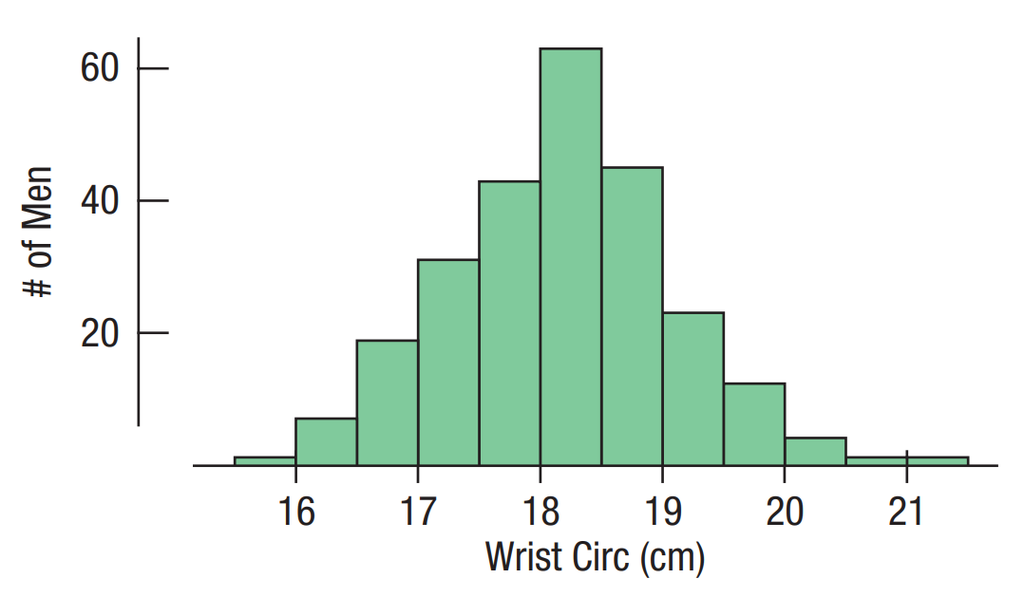

## Undersök om en variabel är normalfördelad

- Vi kan också använda en **normalfördelningsplot** (*normal probability plot*), om variabeln är normalfördelad ligger punkterna i plotten längs en rät linje
- **Exempel:** Bensinförbrukning i mpg (miles per gallon) för en Nissan Maxima insamlat under 8 år av en av kursbokens författare
- Linjen är någorlunda rak – två observationer till vänster är mindre än vad de borde vara, men det är ändå rimligt att se variabeln som normalfördelad

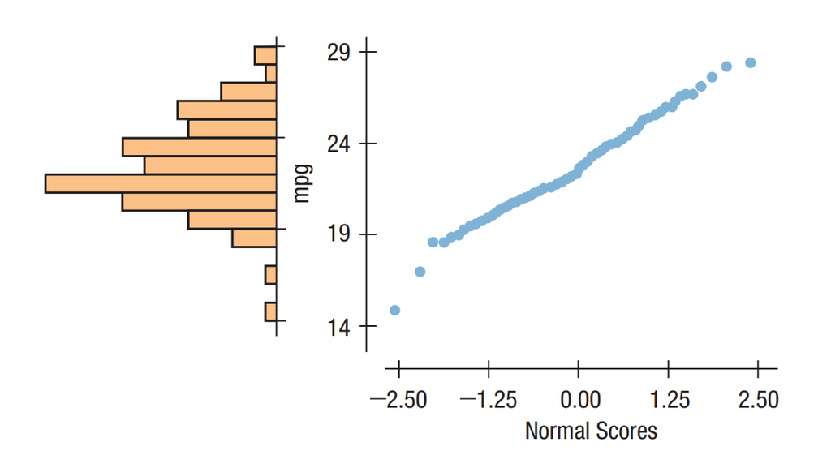

## Undersök om en variabel är normalfördelad

- **Kom ihåg!**
  - Även om en variabel är ungefär normalfördelad så följer den förmodligen inte exakt en normalfördelning
  - Var medveten om att resultaten av beräkningarna därför inte kan förväntas vara så exakta, men förhoppningsvis ge en bra approximation

## Undersök om en variabel är normalfördelad

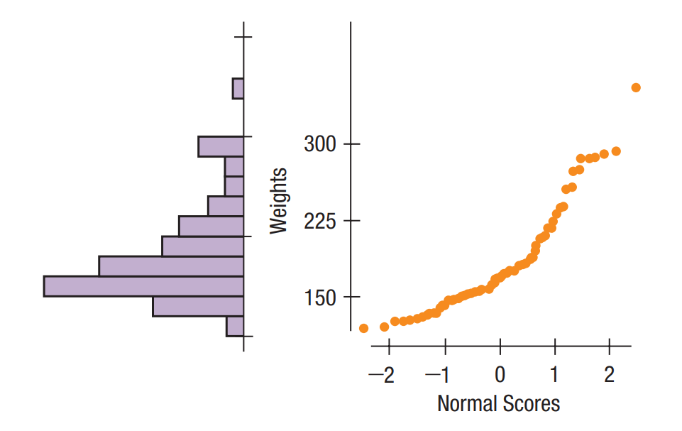

- Här är en normalfördelningsplot och ett histogram ur De Veaux et al. (2021)
- Linjen är inte rak, och dessutom ser vi i histogrammet att fördelningen inte är symmetrisk, utan skev åt höger
- Det vore orimligt att betrakta denna variabel som normalfördelad, och om vi räknade med den som normalfördelad skulle resultaten bli missvisande

## Undersök om en variabel är normalfördelad

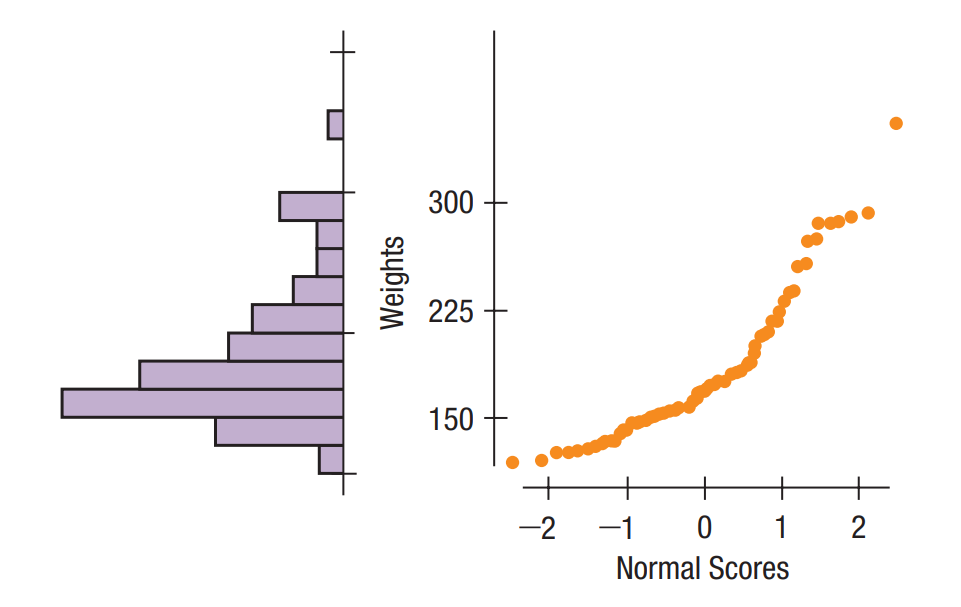

- Det kan gå att göra en variabel som denna normalfördelad med hjälp av en transformation
- Vi såg tidigare att transformationer kan användas för att underlätta jämförelser mellan variabler med låddiagram
- Vi kan också transformera för att göra en variabel normalfördelad

## Undersök om en variabel är normalfördelad

- I R kan vi använda *qqnorm* och *qqline* tillsammans för att göra en normalfördelningsplot, med en linje som visar hur punkterna bör ligga

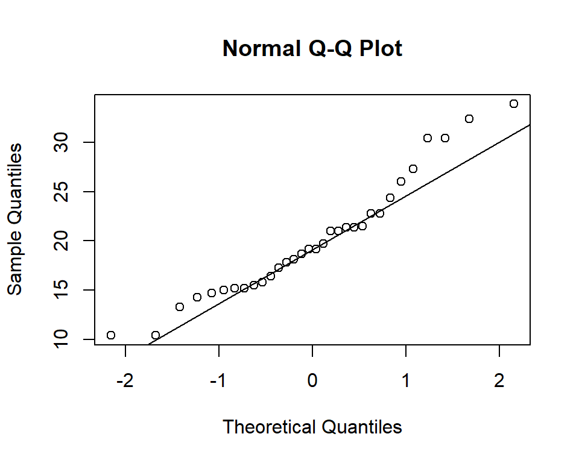

```r
data(mtcars)
qqnorm(mtcars$mpg)
qqline(mtcars$mpg)
```

## Credits

Dessa slides skapades av Karl Sigfrid för kursen Statistik och Dataanalys I och har uppdaterats av Oskar Gustafsson och Valentin Zulj